# Data Merging and Prediction

Application: Predicting calorie consumption (NHANES)

Simon Lee, Jack Taiclet, Eric Li

5/14/2024

# 1. Overview

The goal of this analysis is to explore the relationship between total caloric intake, including beer consumption, and demographic factors. We will utilize some important R tools, including data importing, merging, summarizing by groups, linear and log-linear regression, and making predictions.

# 2. Data Summary

We will use 2 datasets from the National Health and Nutrition Examination Survey (NHANES). The dataset DEMO includes respondents from 2015-16 and 2017-18. The dataset CALORIES was created using the NHANES datasets DR1IFF_I.XPT and DR1IFF_J.XPT (on daily food consumption) and DRXFCD_J.XPT (on food codes) available at: https://wwwn.cdc.gov/nchs/nhanes/Default.aspx.

**DEMO**

- **SEQN:** Respondent’s sequence number
- **AGE:** Respondent’s age (years)
- **GENDER:** Respondent’s biological sex (Male, Female)
- **EDUCATION:** Respondent’s education level (Less than High School, High School, Some College, College Grad)
- **MARITAL:** Respondent’s marital status (Married, Widowed, Divorced, Separated, Single, Living Partner)
- **PREGNANT:** Respondent’s pregnancy status (Yes, No)

**CALORIES**

- **SEQN:** Respondent’s sequence number
- **ALL_CALORIES:** Total calories consumed (food + drinks) by respondent in past 24 hours
- **BEER_CALORIES:** Calories consumed from beer in past 24 hours

Let’s first load some useful libraries.

```r
library(sjPlot)
library(tidyverse)
library(formattable)
library(jtools)
library(scales)
library(ggridges)
library(viridis)
```

Use read.csv() to load the datasets.

```r
setwd("/Users/simonlee/UCLA-Grad-Courses/MGMT298/p4")
DEMO = read.csv("DEMO.csv")
CALORIES = read.csv("CALORIES.csv")
```

# 3. Data Merging

**QUESTION 1:** Use full_join() to merge the datasets using “SEQN” as the common link. Name this new dataset FULL. How many observations are in FULL?

```r
FULL <- full_join(DEMO, CALORIES, by = "SEQN")
n_obs <- nrow(FULL)
n_obs
```

```
## [1] 17675
```

There are 17675 observations

**QUESTION 2:** Use inner_join() to merge the datasets using “SEQN” as the common link. Name this new dataset INNER. How many observations are in INNER?

```r
INNER <- inner_join(DEMO, CALORIES, by = "SEQN")
n_obs_inner <- nrow(INNER)
n_obs_inner
```

```
## [1] 9758
```

There are 9758 observations

We will use INNER in the remainder of the lab, as we want only to include only those individuals with both demographic information and calorie consumption data.

# 4. Data Exploration

**QUESTION 3:** Calculate the mean of ALL calories and BEER calories, by gender.

```r
SUMMARY_GENDER <- INNER %>%
  group_by(GENDER) %>%
  summarise(
    Mean_All_Calories = mean(ALL_CALORIES, na.rm = TRUE),
    Mean_Beer_Calories = mean(BEER_CALORIES, na.rm = TRUE)
  )

formattable(SUMMARY_GENDER, digits = 3)
```

| GENDER | Mean_All_Calories | Mean_Beer_Calories |
| --- | --- | --- |
| Female | 1807 | 14.9 |
| Male | 2398 | 83.7 |

**QUESTION 4:** Consumers with what education level consume the most TOTAL calories? And the most BEER calories?

```r
INNER$EDUCATION <- factor(INNER$EDUCATION, levels = c("College Grad", "Some College", "High School", "Less than High School"))

# Calculating mean calories by education level
SUMMARY_EDUCATION <- INNER %>%
  group_by(EDUCATION) %>%
  summarise(
    Mean_Total_Calories = mean(ALL_CALORIES, na.rm = TRUE),
    Mean_Beer_Calories = mean(BEER_CALORIES, na.rm = TRUE)
  ) %>%
  arrange(desc(Mean_Total_Calories), desc(Mean_Beer_Calories))

# Formatting the table for display with three decimal places
formattable(SUMMARY_EDUCATION, digits = 3)
```

| EDUCATION | Mean_Total_Calories | Mean_Beer_Calories |
| --- | --- | --- |
| College Grad | 2129 | 30.2 |
| Some College | 2125 | 45.7 |
| High School | 2096 | 62.6 |
| Less than High School | 2000 | 57.3 |

# 5. Data Visualization

**QUESTION 5:** Create a ridge plot of total calorie consumption, by gender and education level.

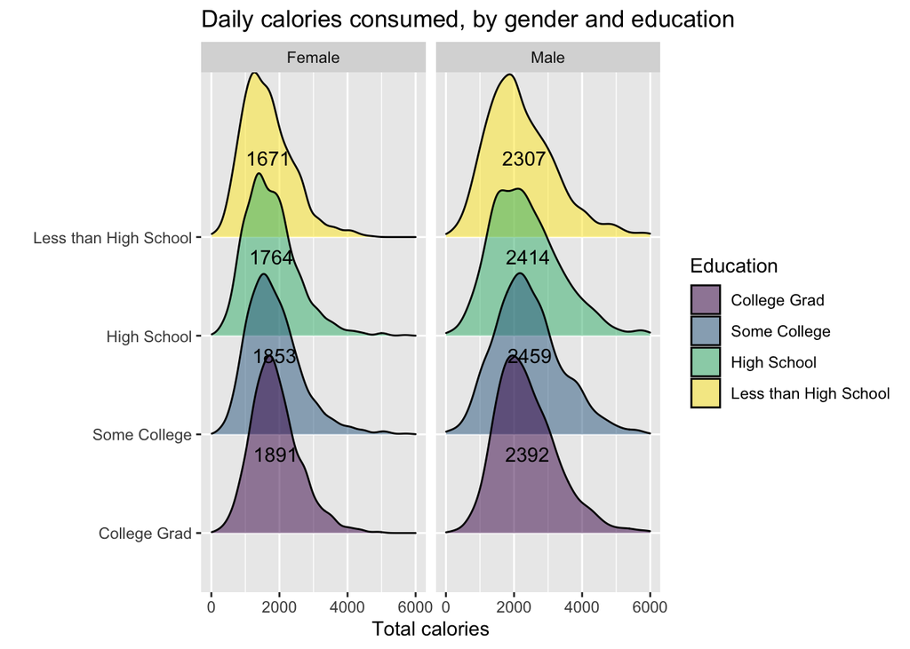

```r
SUMMARY_BOTH = INNER %>%
  group_by(EDUCATION, GENDER) %>%
  summarize(MEAN_ALL=mean(ALL_CALORIES))

ggplot(data=INNER, aes(x=ALL_CALORIES, y=EDUCATION, fill=EDUCATION)) + facet_wrap(~GENDER) +
  geom_density_ridges(alpha=0.5) +
  scale_fill_viridis("Education", discrete = TRUE) +
  scale_x_continuous("Total calories", limits=c(0,6000)) +
  scale_y_discrete("") +
  geom_text(data=SUMMARY_BOTH, aes(x=MEAN_ALL, y=EDUCATION, label=round(MEAN_ALL, digits=0)), nudge_y=0.8) +
  ggtitle("Daily calories consumed, by gender and education")
```

**QUESTION 6:** Create a ridge plot of total calorie consumption, by gender and marital status.

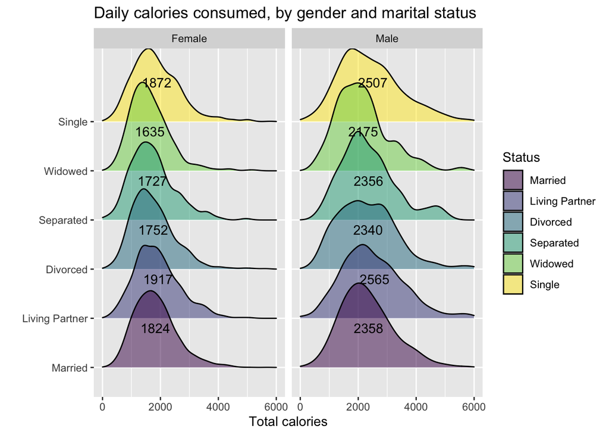

```r
INNER$MARITAL = factor(INNER$MARITAL, levels=c("Married", "Living Partner", "Divorced", "Separated", "Widowed", "Single"))

SUMMARY_MARITAL = INNER %>%
  group_by(MARITAL, GENDER) %>%
  summarize(MEAN_ALL=mean(ALL_CALORIES))

ggplot(data=INNER, aes(x=ALL_CALORIES, y=MARITAL, fill=MARITAL)) + facet_wrap(~GENDER) +
  geom_density_ridges(alpha=0.5) +
  scale_fill_viridis("Status", discrete = TRUE) +
  scale_x_continuous("Total calories", limits=c(0,6000)) +
  scale_y_discrete("") +
  geom_text(data=SUMMARY_MARITAL, aes(x=MEAN_ALL, y=MARITAL, label=round(MEAN_ALL, digits=0)), nudge_y=0.8) +
  ggtitle("Daily calories consumed, by gender and marital status")
```

# 6. Linear Regression Analysis

**QUESTION 7:** Regress ALL calories on age, gender, education and marital status using the INNER data. Which variable(s) are significant?

```r
regression1 <- lm(ALL_CALORIES ~ AGE + GENDER + EDUCATION + MARITAL, data = INNER)
summ(regression1, digits=2)
```

```
## MODEL INFO:
## Observations: 9758
## Dependent Variable: ALL_CALORIES
## Type: OLS linear regression
##
## MODEL FIT:
## F(10,9747) = 134.56, p = 0.00
## R² = 0.12
## Adj. R² = 0.12
##
## Standard errors: OLS
## -------------------------------------------------------------
##                                  Est.    S.E.   t val.      p
## --------------------------- --------- ------- -------- ------
## (Intercept)                   2347.71   39.34    59.67   0.00
## AGE                            -10.10    0.64   -15.78   0.00
## GENDERMale                     605.25   19.17    31.57   0.00
## EDUCATIONSome College            9.96   25.51     0.39   0.70
## EDUCATIONHigh School           -41.08   27.50    -1.49   0.14
## EDUCATIONLess than High       -109.69   28.37    -3.87   0.00
## School
## MARITALLiving Partner           25.42   34.57     0.74   0.46
## MARITALDivorced                 10.42   31.62     0.33   0.74
## MARITALSeparated               -46.85   51.38    -0.91   0.36
## MARITALWidowed                  28.14   39.45     0.71   0.48
## MARITALSingle                  -71.06   27.93    -2.54   0.01
## -------------------------------------------------------------
```

The age, gender-male, EDUCATIONLess than High school and marital single are all statistically significant.

**QUESTION 8:** Regress ALL calories on gender and pregnancy status using the INNER data. What is your interpretation of the pregnant variable?

```r
regression2 <- lm(ALL_CALORIES ~ GENDER + PREGNANT, data = INNER)
summ(regression2, digits=2)
```

```
## MODEL INFO:
## Observations: 9758
## Dependent Variable: ALL_CALORIES
## Type: OLS linear regression
##
## MODEL FIT:
## F(2,9755) = 480.20, p = 0.00
## R² = 0.09
## Adj. R² = 0.09
##
## Standard errors: OLS
## ---------------------------------------------------
##                        Est.    S.E.   t val.      p
## ----------------- --------- ------- -------- ------
## (Intercept)         1800.66   13.48   133.62   0.00
## GENDERMale           596.90   19.26    30.99   0.00
## PREGNANTYes          307.61   90.77     3.39   0.00
## ---------------------------------------------------
```

Here are the interpretations of the pregnancy variable on all statistical measures. Coefficient (Est.): The coefficient for PREGNANTYes is 307.61. This suggests that, all else being equal, pregnant individuals consume an average of 307.61 more calories compared to non-pregnant individuals.

Standard Error (S.E.): The standard error of this estimate is 90.77, which measures the average amount that the coefficient ‘PREGNANTYes’ would differ if the model were estimated multiple times using different samples from the same population.

t-Value: The t-value is 3.39. This is a measure of how many standard deviations the estimated coefficient is far from 0. It helps determine if the coefficient is significantly different from 0 (no effect).

p-Value: The p-value associated with the PREGNANTYes coefficient is 0.00, indicating that the effect of being pregnant on calorie consumption is statistically significant.

# 7. Logistic Regression Analysis

**QUESTION 9:** Create a new binary variable called BEER_DRINKER if a person consumes any beer calories. How many beer drinkers are in the data?

```r
INNER$BEER_DRINKER <- ifelse(INNER$BEER_CALORIES > 0, 1, 0)

beer_drinker_count <- table(INNER$BEER_DRINKER)
beer_drinker_count
```

```
##
##    0    1
## 8679 1079
```

There are 1079 people who drink beer.

**QUESTION 10:** Run a logistic regression on BEER_DRINKER with age, gender, education and marital status as independent variables. Which variable(s) are significant?

```r
logit1 <- glm(BEER_DRINKER ~ AGE + GENDER + EDUCATION + MARITAL,
              data = INNER, family = binomial())
summ(logit1, exp=TRUE, digits=2)
```

```
## MODEL INFO:
## Observations: 9758
## Dependent Variable: BEER_DRINKER
## Type: Generalized linear model
##   Family: binomial
##   Link function: logit
##
## MODEL FIT:
## χ²(10) = 530.20, p = 0.00
## Pseudo-R² (Cragg-Uhler) = 0.11
## Pseudo-R² (McFadden) = 0.08
## AIC = 6277.87, BIC = 6356.91
##
## Standard errors: MLE
## ----------------------------------------------------------------------
##                               exp(Est.)   2.5%   97.5%   z val.      p
## --------------------------- ----------- ------ ------- -------- ------
## (Intercept)                        0.07   0.05    0.10   -17.78   0.00
## AGE                                0.99   0.98    0.99    -6.02   0.00
## GENDERMale                         4.42   3.79    5.14    19.17   0.00
## EDUCATIONSome College              1.25   1.04    1.51     2.42   0.02
## EDUCATIONHigh School               1.32   1.09    1.60     2.81   0.00
## EDUCATIONLess than High            1.16   0.95    1.42     1.45   0.15
## School
## MARITALLiving Partner              1.50   1.21    1.86     3.74   0.00
## MARITALDivorced                    1.37   1.10    1.71     2.77   0.01
## MARITALSeparated                   1.32   0.92    1.89     1.52   0.13
## MARITALWidowed                     1.05   0.74    1.48     0.26   0.79
## MARITALSingle                      1.14   0.94    1.37     1.33   0.18
## ----------------------------------------------------------------------
```

The Age, being male, education college, high school, having a partner, being divorced are all statistically significant.

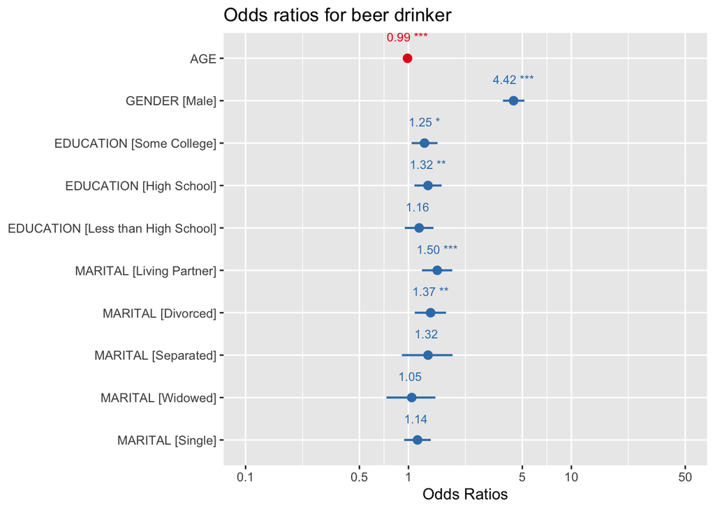

```r
plot_model(logit1, show.values = TRUE, value.size=3, value.offset=0.5) +
  ggtitle("Odds ratios for beer drinker")
```

**QUESTION 11:** Run a logistic regression on BEER_DRINKER with gender and pregnancy status as independent variables. Which variable(s) are significant?

```r
logit2 <- glm(BEER_DRINKER ~ GENDER + PREGNANT,
              data = INNER, family = binomial())
summ(logit2, exp=TRUE, digits=2)
```

```
## MODEL INFO:
## Observations: 9758
## Dependent Variable: BEER_DRINKER
## Type: Generalized linear model
##   Family: binomial
##   Link function: logit
##
## MODEL FIT:
## χ²(2) = 435.34, p = 0.00
## Pseudo-R² (Cragg-Uhler) = 0.09
## Pseudo-R² (McFadden) = 0.06
## AIC = 6356.73, BIC = 6378.28
##
## Standard errors: MLE
## ------------------------------------------------------------
##                     exp(Est.)   2.5%   97.5%   z val.      p
## ----------------- ----------- ------ ------- -------- ------
## (Intercept)              0.05   0.04    0.06   -44.90   0.00
## GENDERMale               4.21   3.62    4.88    18.81   0.00
## PREGNANTYes              0.36   0.09    1.46    -1.43   0.15
## ------------------------------------------------------------
```

Being male is significant but not being pregnant.

Finally, let’s use regression 1 to make a prediction for a friend, a 25-year old single man who graduated college. We first create a small dataframe called FRIEND and enter some input values for the regression.

```r
FRIEND = data.frame(
  AGE = 25,
  GENDER = "Male",
  EDUCATION = "College Grad",
  MARITAL = "Single"
)
```

Then we enter the input data into the predict() command. We can also obtain a 95% prediction interval.

```r
predict(regression1, newdata = FRIEND, interval = "prediction")
```

```
##        fit      lwr      upr
## 1 2629.513 806.5477 4452.479
```

**QUESTION 12:** Your neighbor is a 32-year old female Instagram influencer who attended some college and is living with a partner. What is her predicted calorie consumption?

```r
# Creating a data frame for the neighbor
NEIGHBOR = data.frame(
  AGE = 32,
  GENDER = "Female",
  EDUCATION = "Some College",
  MARITAL = "Living Partner"
)

# Making a prediction using the regression model
predicted_calories = predict(regression1, newdata = NEIGHBOR, interval = "prediction")
predicted_calories
```

```
##        fit      lwr      upr
## 1 2060.038 236.7714 3883.305
```